# Binomial Logistic Regression for Colorectal Cancer Microbiome Classification

Harshini Chintala

2026-09-03

## 0.1 Notebook roadmap

**Purpose:** This notebook is one reproducible component of the CRC microbiome classification pipeline.

**Execution order** 1. Load the project environment and fixed random seed (`1910`). 2. Load only the validated project artifacts required for this analysis. 3. Perform the analysis exactly as documented below. 4. Generate tables/figures and save machine-readable outputs. 5. Record the session information used for the run.

**Output contract:** generated tables, figures, model objects, audit files, and session information are written under `02 Classical ML/results/`. The notebook itself renders to HTML with a floating table of contents, so the sections can be navigated from the left-hand panel in the knitted document.

**Reproducibility rule:** this repository preserves the validated analysis logic and project-wide seed. Environment restoration is handled by `renv.lock` for R and `requirements.txt` for Python. The notebooks do not silently install unpinned packages during knitting.

### 0.1.1 Reproducibility constants

- Project seed: **1910**
- Discovery cohort: **ZellerG_2014**
- Primary task: **Healthy vs CRC; adenoma excluded**
- Frozen discovery split: **92 training / 22 held-out test samples**
- Primary feature panel: **20 Boruta-selected features**
- External cohorts: **FengQ_2015** and **VogtmannE_2016**

# 1 Load Dataset

```r
# ==========================================================
# Load Dataset
# ==========================================================

library(curatedMetagenomicData)
library(TreeSummarizedExperiment)
library(tidyverse)
library(dplyr)
library(caret)
library(Boruta)
library(pROC)

# Download/load Zeller dataset
zeller <- curatedMetagenomicData(
  "ZellerG_2014.relative_abundance",
  dryrun = FALSE
)[[1]]

# Extract abundance matrix
abundance <- assay(zeller)

# Transpose:
# Rows = samples
# Columns = microbial species
X <- as.data.frame(t(abundance))

# Disease labels
y <- colData(zeller)$study_condition

# Combine into one dataframe
crc_data <- X
crc_data$disease <- y

# Check dimensions
dim(crc_data)
```

```
## [1] 156 653
```

```r
# Class distribution
table(crc_data$disease)
```

```
##
## adenoma control     CRC
##      42      61      53
```

# 2 Create Binary Dataset

```r
# 2. Create Binary Dataset
# ========================
binary_data <- crc_data %>%
  # 1. Rename "control" to "healthy" before filtering
  mutate(disease = case_match(disease, "control" ~ "healthy", .default = disease)) %>%
  # 2. Filter down to your desired classes
  filter(disease %in% c("healthy", "CRC"))

# 3. Clean up the factor levels so "adenoma" is removed completely
binary_data$disease <- factor(binary_data$disease)

table(binary_data$disease)
```

```
##
##     CRC healthy
##      53      61
```

# 3 Train-Test Split

```r
# ==========================================================
# Shared Train-Test Split
# ==========================================================

train_index_path <- file.path(
  models_dir,
  "BinaryClass_Train_Index.rds"
)

if (file.exists(train_index_path)) {

  train_index <- readRDS(train_index_path)

} else {

  set.seed(1910)

  train_index <- createDataPartition(
    binary_data$disease,
    p = 0.80,
    list = FALSE
  )

  saveRDS(
    train_index,
    train_index_path
  )
}

train_data <- binary_data[train_index, ]
test_data  <- binary_data[-train_index, ]

cat("Training samples :", nrow(train_data), "\n")
## Training samples : 92
cat("Testing samples  :", nrow(test_data), "\n")
## Testing samples  : 22

table(train_data$disease)
```

```
##
##     CRC healthy
##      43      49
```

```r
table(test_data$disease)
```

```
##
##     CRC healthy
##      10      12
```

```r
#==========================================================
# Prepare Predictor Matrix
#==========================================================

X_train_raw <- train_data %>%
  dplyr::select(-disease)

X_test_raw <- test_data %>%
  dplyr::select(-disease)

y_train <- train_data$disease
y_test <- test_data$disease
```

# 4 Near-Zero Variance Filtering

```r
#==========================================================
# Near-Zero Variance Filtering
#==========================================================

# Detect near-zero variance features ONLY on training data
nzv <- nearZeroVar(X_train_raw)

cat("Near-zero variance features removed:", length(nzv), "\n")
## Near-zero variance features removed: 380

# Remove the same columns from train and test
X_train_nzv <- X_train_raw[, -nzv, drop = FALSE]
X_test_nzv  <- X_test_raw[, -nzv, drop = FALSE]

cat("Remaining features:", ncol(X_train_nzv), "\n")
## Remaining features: 272
```

# 5 Feature Selection using Boruta

```r
#---------------------------------------------------------------
# Feature Selection using Boruta
#---------------------------------------------------------------

set.seed(1910)

boruta_data <- data.frame(
  Disease = y_train,
  X_train_nzv,
  check.names = FALSE
)

boruta_model <- Boruta(
  Disease ~ .,
  data = boruta_data,
  doTrace = 2
)

boruta_final <- TentativeRoughFix(boruta_model)

selected_features <- getSelectedAttributes(
  boruta_final,
  withTentative = FALSE
)

# ==========================================================
# Save Canonical Shared Binary Feature List
# ==========================================================

canonical_feature_list <- data.frame(
  Feature = selected_features,
  stringsAsFactors = FALSE
)

write.csv(
  canonical_feature_list,
  file.path(
    results_dir,
    "Binary_Selected_20_Features.csv"
  ),
  row.names = FALSE
)

cat(
  "Canonical shared binary feature list saved successfully.\n"
)
## Canonical shared binary feature list saved successfully.

cat("Number of selected features:",
    length(selected_features), "\n")
## Number of selected features: 20

stopifnot(length(selected_features) == 20)

print(selected_features)
```

```
##  [1] "k__Bacteria|p__Firmicutes|c__Clostridia|o__Clostridiales|f__Lachnospiraceae|g__Anaerostipes|s__Anaerostipes_hadrus"
##  [2] "k__Bacteria|p__Firmicutes|c__Clostridia|o__Clostridiales|f__Lachnospiraceae|g__Lachnospiraceae_unclassified|s__Eubacterium_rectale"
##  [3] "k__Bacteria|p__Firmicutes|c__Clostridia|o__Clostridiales|f__Eubacteriaceae|g__Eubacterium|s__Eubacterium_hallii"
##  [4] "k__Bacteria|p__Bacteroidetes|c__Bacteroidia|o__Bacteroidales|f__Bacteroidaceae|g__Bacteroides|s__Bacteroides_uniformis"
##  [5] "k__Bacteria|p__Firmicutes|c__Clostridia|o__Clostridiales|f__Ruminococcaceae|g__Ruminococcus|s__Ruminococcus_bicirculans"
##  [6] "k__Bacteria|p__Firmicutes|c__Clostridia|o__Clostridiales|f__Oscillospiraceae|g__Oscillibacter|s__Oscillibacter_sp_CAG_241"
##  [7] "k__Bacteria|p__Firmicutes|c__Clostridia|o__Clostridiales|f__Lachnospiraceae|g__Blautia|s__Blautia_wexlerae"
##  [8] "k__Bacteria|p__Firmicutes|c__Clostridia|o__Clostridiales|f__Ruminococcaceae|g__Ruthenibacterium|s__Ruthenibacterium_lactatiformans"
##  [9] "k__Bacteria|p__Proteobacteria|c__Deltaproteobacteria|o__Desulfovibrionales|f__Desulfovibrionaceae|g__Bilophila|s__Bilophila_wadsworthia"
## [10] "k__Bacteria|p__Firmicutes|c__Bacilli|o__Lactobacillales|f__Streptococcaceae|g__Streptococcus|s__Streptococcus_salivarius"
## [11] "k__Bacteria|p__Firmicutes|c__Clostridia|o__Clostridiales|f__Peptostreptococcaceae|g__Intestinibacter|s__Intestinibacter_bartlettii"
## [12] "k__Bacteria|p__Proteobacteria|c__Betaproteobacteria|o__Burkholderiales|f__Sutterellaceae|g__Turicimonas|s__Turicimonas_muris"
## [13] "k__Bacteria|p__Firmicutes|c__Tissierellia|o__Tissierellales|f__Peptoniphilaceae|g__Parvimonas|s__Parvimonas_micra"
## [14] "k__Bacteria|p__Firmicutes|c__Clostridia|o__Clostridiales|f__Ruminococcaceae|g__Flavonifractor|s__Flavonifractor_plautii"
## [15] "k__Bacteria|p__Firmicutes|c__Clostridia|o__Clostridiales|f__Clostridiaceae|g__Hungatella|s__Hungatella_hathewayi"
## [16] "k__Bacteria|p__Firmicutes|c__Negativicutes|o__Veillonellales|f__Veillonellaceae|g__Dialister|s__Dialister_pneumosintes"
## [17] "k__Bacteria|p__Firmicutes|c__Clostridia|o__Clostridiales|f__Peptostreptococcaceae|g__Peptostreptococcus|s__Peptostreptococcus_stomatis"
## [18] "k__Bacteria|p__Proteobacteria|c__Deltaproteobacteria|o__Desulfovibrionales|f__Desulfovibrionaceae|g__Desulfovibrio|s__Desulfovibrio_piger"
## [19] "k__Bacteria|p__Firmicutes|c__Clostridia|o__Clostridiales|f__Clostridiales_Family_XIII_Incertae_Sedis|g__Mogibacterium|s__Mogibacterium_timidum"
## [20] "k__Bacteria|p__Fusobacteria|c__Fusobacteriia|o__Fusobacteriales|f__Fusobacteriaceae|g__Fusobacterium|s__Fusobacterium_nucleatum"
```

```r
X_train_boruta <- X_train_nzv[, selected_features, drop = FALSE]
X_test_boruta  <- X_test_nzv[, selected_features, drop = FALSE]
```

```r
saveRDS(
  boruta_model,
  file.path(
    models_dir,
    "Boruta_Model.rds"
  )
)

cat("Boruta model saved successfully.\n")
## Boruta model saved successfully.
```

# 6 Feature Scaling

```r
# ==========================================================
# Feature Scaling
# ==========================================================

# Learn scaling parameters ONLY from training data
scaler <- preProcess(
  X_train_boruta,
  method = c("center", "scale")
)

X_train_scaled <- predict(scaler, X_train_boruta)
X_test_scaled  <- predict(scaler, X_test_boruta)

ncol(X_test_scaled)
```

```
## [1] 20
```

```r
head(colnames(X_test_scaled))
```

```
## [1] "k__Bacteria|p__Firmicutes|c__Clostridia|o__Clostridiales|f__Lachnospiraceae|g__Anaerostipes|s__Anaerostipes_hadrus"
## [2] "k__Bacteria|p__Firmicutes|c__Clostridia|o__Clostridiales|f__Lachnospiraceae|g__Lachnospiraceae_unclassified|s__Eubacterium_rectale"
## [3] "k__Bacteria|p__Firmicutes|c__Clostridia|o__Clostridiales|f__Eubacteriaceae|g__Eubacterium|s__Eubacterium_hallii"
## [4] "k__Bacteria|p__Bacteroidetes|c__Bacteroidia|o__Bacteroidales|f__Bacteroidaceae|g__Bacteroides|s__Bacteroides_uniformis"
## [5] "k__Bacteria|p__Firmicutes|c__Clostridia|o__Clostridiales|f__Ruminococcaceae|g__Ruminococcus|s__Ruminococcus_bicirculans"
## [6] "k__Bacteria|p__Firmicutes|c__Clostridia|o__Clostridiales|f__Oscillospiraceae|g__Oscillibacter|s__Oscillibacter_sp_CAG_241"
```

```r
anyDuplicated(colnames(X_test_scaled))
```

```
## [1] 0
```

```r
cat("Training data scaled successfully.\n")
## Training data scaled successfully.
cat("Testing data scaled successfully.\n")
## Testing data scaled successfully.
```

```r
saveRDS(
  scaler,
  file.path(
    models_dir,
    "Scaler.rds"
  )
)

cat("Scaler saved successfully.\n")
## Scaler saved successfully.
```

```r
#===============================================================
# Standardize Feature Names
#===============================================================

colnames(X_train_scaled) <- make.names(colnames(X_train_scaled))
colnames(X_test_scaled)  <- make.names(colnames(X_test_scaled))

cat("Feature names standardized successfully.\n")
## Feature names standardized successfully.
```

# 7 Repeated Stratified Cross-Validation

```r
# ===============================================================
# Shared Repeated Stratified Cross-Validation
# ===============================================================

cv_folds_path <- file.path(
  models_dir,
  "BinaryClass_CV_Folds.rds"
)

if (file.exists(cv_folds_path)) {

  cv_folds <- readRDS(cv_folds_path)

} else {

  set.seed(1910)

  cv_folds <- createMultiFolds(
    y_train,
    k = 10,
    times = 5
  )

  saveRDS(
    cv_folds,
    cv_folds_path
  )
}

shared_cv_control <- trainControl(
  method = "repeatedcv",
  number = 10,
  repeats = 5,
  index = cv_folds,
  classProbs = TRUE,
  savePredictions = "final",
  summaryFunction = twoClassSummary
)
```

```r
#===============================================================
# Train Binary Logistic Regression
#===============================================================

train_data <- data.frame(
  Disease = y_train,
  X_train_scaled,
  check.names = FALSE
)
set.seed(1910)

logistic_model <- caret::train(
  Disease ~ .,
  data = train_data,
  method = "glm",
  family = binomial(),
  metric = "ROC",
  trControl = shared_cv_control
)

logistic_model
## Generalized Linear Model
##
## 92 samples
## 20 predictors
##  2 classes: 'CRC', 'healthy'
##
## No pre-processing
## Resampling: Cross-Validated (10 fold, repeated 5 times)
## Summary of sample sizes: 83, 83, 83, 82, 83, 82, ...
## Resampling results:
##
##   ROC     Sens   Spec
##   0.7957  0.782  0.792
```

```r
#===============================================================
# Prepare Test Data
#===============================================================

test_model_data <- data.frame(
  X_test_scaled,
  check.names = FALSE
)
```

# 8 Cross-Validation Results

```r
#===============================================================
# Cross-Validation Results
#===============================================================

print(logistic_model)
## Generalized Linear Model
##
## 92 samples
## 20 predictors
##  2 classes: 'CRC', 'healthy'
##
## No pre-processing
## Resampling: Cross-Validated (10 fold, repeated 5 times)
## Summary of sample sizes: 83, 83, 83, 82, 83, 82, ...
## Resampling results:
##
##   ROC     Sens   Spec
##   0.7957  0.782  0.792

logistic_model$results
```

|  | parameter | ROC | Sens | Spec | ROCSD | SensSD | SpecSD |
| --- | --- | --- | --- | --- | --- | --- | --- |
| 1 | none | 0.7957 | 0.782 | 0.792 | 0.1543122 | 0.2132738 | 0.2066151 |

```r
cv_results <- logistic_model$results

write.csv(
    cv_results,
    file.path(
        results_dir,
        "BinomialLR_CrossValidation.csv"
    ),
    row.names = FALSE
)
```

# 9 Variance Inflation Factor (VIF)

```r
#===============================================================
# Variance Inflation Factor (VIF)
#===============================================================

vif_values <- car::vif(logistic_model$finalModel)


vif_table <- data.frame(
  Feature = names(vif_values),
  VIF = vif_values
)

vif_table
```

|  | Feature | VIF |
| --- | --- | --- |
| k__Bacteria.p__Firmicutes.c__Clostridia.o__Clostridiales.f__Lachnospiraceae.g__Anaerostipes.s__Anaerostipes_hadrus | k__Bacteria.p__Firmicutes.c__Clostridia.o__Clostridiales.f__Lachnospiraceae.g__Anaerostipes.s__Anaerostipes_hadrus | 2.626908 |
| k__Bacteria.p__Firmicutes.c__Clostridia.o__Clostridiales.f__Lachnospiraceae.g__Lachnospiraceae_unclassified.s__Eubacterium_rectale | k__Bacteria.p__Firmicutes.c__Clostridia.o__Clostridiales.f__Lachnospiraceae.g__Lachnospiraceae_unclassified.s__Eubacterium_rectale | 7.688741 |
| k__Bacteria.p__Firmicutes.c__Clostridia.o__Clostridiales.f__Eubacteriaceae.g__Eubacterium.s__Eubacterium_hallii | k__Bacteria.p__Firmicutes.c__Clostridia.o__Clostridiales.f__Eubacteriaceae.g__Eubacterium.s__Eubacterium_hallii | 10.191069 |
| k__Bacteria.p__Bacteroidetes.c__Bacteroidia.o__Bacteroidales.f__Bacteroidaceae.g__Bacteroides.s__Bacteroides_uniformis | k__Bacteria.p__Bacteroidetes.c__Bacteroidia.o__Bacteroidales.f__Bacteroidaceae.g__Bacteroides.s__Bacteroides_uniformis | 4.325930 |
| k__Bacteria.p__Firmicutes.c__Clostridia.o__Clostridiales.f__Ruminococcaceae.g__Ruminococcus.s__Ruminococcus_bicirculans | k__Bacteria.p__Firmicutes.c__Clostridia.o__Clostridiales.f__Ruminococcaceae.g__Ruminococcus.s__Ruminococcus_bicirculans | 16.996802 |
| k__Bacteria.p__Firmicutes.c__Clostridia.o__Clostridiales.f__Oscillospiraceae.g__Oscillibacter.s__Oscillibacter_sp_CAG_241 | k__Bacteria.p__Firmicutes.c__Clostridia.o__Clostridiales.f__Oscillospiraceae.g__Oscillibacter.s__Oscillibacter_sp_CAG_241 | 10.163838 |
| k__Bacteria.p__Firmicutes.c__Clostridia.o__Clostridiales.f__Lachnospiraceae.g__Blautia.s__Blautia_wexlerae | k__Bacteria.p__Firmicutes.c__Clostridia.o__Clostridiales.f__Lachnospiraceae.g__Blautia.s__Blautia_wexlerae | 35.914675 |
| k__Bacteria.p__Firmicutes.c__Clostridia.o__Clostridiales.f__Ruminococcaceae.g__Ruthenibacterium.s__Ruthenibacterium_lactatiformans | k__Bacteria.p__Firmicutes.c__Clostridia.o__Clostridiales.f__Ruminococcaceae.g__Ruthenibacterium.s__Ruthenibacterium_lactatiformans | 1.588728 |
| k__Bacteria.p__Proteobacteria.c__Deltaproteobacteria.o__Desulfovibrionales.f__Desulfovibrionaceae.g__Bilophila.s__Bilophila_wadsworthia | k__Bacteria.p__Proteobacteria.c__Deltaproteobacteria.o__Desulfovibrionales.f__Desulfovibrionaceae.g__Bilophila.s__Bilophila_wadsworthia | 3.771971 |
| k__Bacteria.p__Firmicutes.c__Bacilli.o__Lactobacillales.f__Streptococcaceae.g__Streptococcus.s__Streptococcus_salivarius | k__Bacteria.p__Firmicutes.c__Bacilli.o__Lactobacillales.f__Streptococcaceae.g__Streptococcus.s__Streptococcus_salivarius | 64.358902 |

[output cut: 10 more lines]

```r
write.csv(
  vif_table,
  file.path(
    results_dir,
    "BinomialLR_VIF.csv"
  ),
  row.names = FALSE
)
```

# 10 Predict Probabilities

```r
#===============================================================
# Predict Probabilities
#===============================================================

prob_predictions <- predict(
  logistic_model,
  newdata = X_test_scaled,
  type = "prob"
)

head(prob_predictions)
```

|  | CRC | healthy |
| --- | --- | --- |
| CCIS00281083ST-3-0 | 0.37248818574857 | 0.6275118142514274355293 |
| CCIS03857607ST-4-0 | 0.96915396159627 | 0.0308460384037335770546 |
| CCIS06260551ST-3-0 | 1.00000000000000 | 0.0000000000000002220446 |
| CCIS07648107ST-4-0 | 0.00636563844387 | 0.9936343615561343822762 |
| CCIS11362406ST-4-0 | 0.00000003011672 | 0.9999999698832764405410 |
| CCIS12656533ST-4-0 | 1.00000000000000 | 0.0000000000000002220446 |

```r
summary(prob_predictions)
```

```
##       CRC              healthy
##  Min.   :0.000000   Min.   :0.0000000
##  1st Qu.:0.001453   1st Qu.:0.0003395
##  Median :0.258402   Median :0.7415975
##  Mean   :0.455141   Mean   :0.5448588
##  3rd Qu.:0.999660   3rd Qu.:0.9985470
##  Max.   :1.000000   Max.   :1.0000000
```

# 11 Convert Probabilities to Predicted Classes

```r
#===============================================================
# Predict Classes
#===============================================================

predicted_class <- predict(
  logistic_model,
  newdata = X_test_scaled,
  type = "raw"
)

head(predicted_class)
```

```
## [1] healthy CRC     CRC     healthy healthy CRC
## Levels: CRC healthy
```

```r
table(predicted_class)
## predicted_class
##     CRC healthy
##      10      12
```

```r
#===============================================================
# Save Predictions
#===============================================================

prediction_results <- data.frame(
  SampleID = rownames(test_data),
  Actual = y_test,
  Predicted = predicted_class,
  Probability_CRC = prob_predictions$CRC,
  Probability_Healthy = prob_predictions$healthy,
  row.names = NULL
)
head(prediction_results)
```

|  | SampleID | Actual | Predicted | Probability_CRC | Probability_Healthy |
| --- | --- | --- | --- | --- | --- |
| 1 | CCIS00281083ST-3-0 | healthy | healthy | 0.37248818574857 | 0.6275118142514274355293 |
| 2 | CCIS03857607ST-4-0 | healthy | CRC | 0.96915396159627 | 0.0308460384037335770546 |
| 3 | CCIS06260551ST-3-0 | CRC | CRC | 1.00000000000000 | 0.0000000000000002220446 |
| 4 | CCIS07648107ST-4-0 | healthy | healthy | 0.00636563844387 | 0.9936343615561343822762 |
| 5 | CCIS11362406ST-4-0 | healthy | healthy | 0.00000003011672 | 0.9999999698832764405410 |
| 6 | CCIS12656533ST-4-0 | CRC | CRC | 1.00000000000000 | 0.0000000000000002220446 |

```r
write.csv(
  prediction_results,
  file.path(
    results_dir,
    "BinomialLR_Predictions.csv"
  ),
  row.names = FALSE
)

cat("Predictions saved successfully.\n")
## Predictions saved successfully.
```

# 12 Confusion Matrix

```r
#===============================================================
# Confusion Matrix
#===============================================================

confusion_matrix <- confusionMatrix(
  predicted_class,
  y_test,
  positive = "CRC"
)

confusion_matrix
## Confusion Matrix and Statistics
##
##           Reference
## Prediction CRC healthy
##    CRC       8       2
##    healthy   2      10
##
##                Accuracy : 0.8182
##                  95% CI : (0.5972, 0.9481)
##     No Information Rate : 0.5455
##     P-Value [Acc > NIR] : 0.007436
##
##                   Kappa : 0.6333
##
##  Mcnemar's Test P-Value : 1.000000
##
##             Sensitivity : 0.8000
##             Specificity : 0.8333
##          Pos Pred Value : 0.8000
##          Neg Pred Value : 0.8333
##              Prevalence : 0.4545
##          Detection Rate : 0.3636
##    Detection Prevalence : 0.4545
##       Balanced Accuracy : 0.8167
##
##        'Positive' Class : CRC
##
```

```r
#===============================================================
# Save Confusion Matrix
#===============================================================

capture.output(
  confusion_matrix,
  file = file.path(
    results_dir,
    "BinomialLR_ConfusionMatrix.txt"
  )
)

cat("Confusion matrix saved successfully.\n")
## Confusion matrix saved successfully.
```

# 13 Confusion Matrix Heatmap

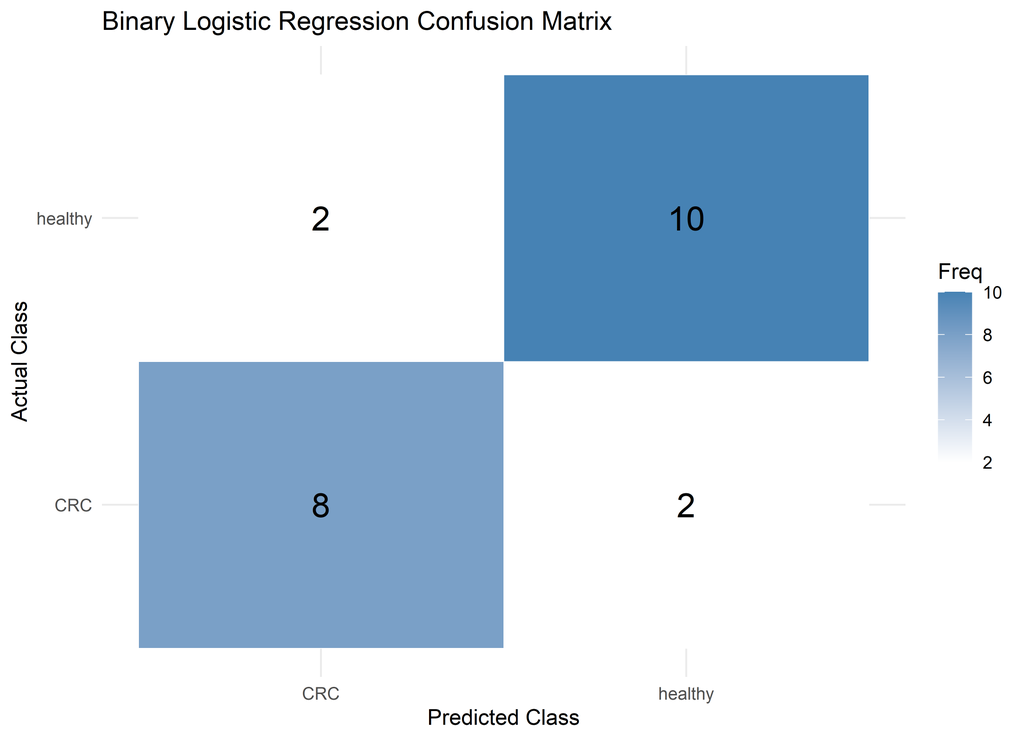

```r
#===============================================================
# Confusion Matrix Heatmap
#===============================================================

confusion_df <- as.data.frame(confusion_matrix$table)

ggplot(confusion_df, aes(
  x = Prediction,
  y = Reference,
  fill = Freq
)) +
  geom_tile(color = "white") +
  geom_text(aes(label = Freq), size = 6) +
  scale_fill_gradient(
    low = "white",
    high = "steelblue"
  ) +
  labs(
    title = "Binary Logistic Regression Confusion Matrix",
    x = "Predicted Class",
    y = "Actual Class"
  ) +
  theme_minimal()
```

```r
ggsave(
  filename = file.path(
    figures_dir,
    "BinomialLR_ConfusionMatrixHeatmap.png"
  ),
  width = 6,
  height = 5,
  dpi = 300
)
```

# 14 Overall Metrics

```r
#===============================================================
# Overall Evaluation Metrics
#===============================================================

overall_metrics <- data.frame(
  Accuracy = confusion_matrix$overall["Accuracy"],
  Kappa = confusion_matrix$overall["Kappa"],
  AccuracyLower = confusion_matrix$overall["AccuracyLower"],
  AccuracyUpper = confusion_matrix$overall["AccuracyUpper"],
  AccuracyPValue = confusion_matrix$overall["AccuracyPValue"],
  McNemarPValue = confusion_matrix$overall["McnemarPValue"]
)

overall_metrics
```

|  | Accuracy | Kappa | AccuracyLower | AccuracyUpper | AccuracyPValue | McNemarPValue |
| --- | --- | --- | --- | --- | --- | --- |
| Accuracy | 0.8181818 | 0.6333333 | 0.5971542 | 0.9481327 | 0.007435623 | 1 |

```r
write.csv(
  overall_metrics,
  file.path(
    results_dir,
    "BinomialLR_OverallMetrics.csv"
  ),
  row.names = FALSE
)

cat("Overall metrics saved successfully.\n")
## Overall metrics saved successfully.
```

# 15 Class-wise Metrics

```r
#===============================================================
# Class-wise Evaluation Metrics
#===============================================================

class_metrics <- as.data.frame(
  confusion_matrix$byClass
)

class_metrics$Metric <- rownames(class_metrics)

rownames(class_metrics) <- NULL

class_metrics
```

| confusion_matrix$byClass | Metric |
| --- | --- |
| 0.8000000 | Sensitivity |
| 0.8333333 | Specificity |
| 0.8000000 | Pos Pred Value |
| 0.8333333 | Neg Pred Value |
| 0.8000000 | Precision |
| 0.8000000 | Recall |
| 0.8000000 | F1 |
| 0.4545455 | Prevalence |
| 0.3636364 | Detection Rate |
| 0.4545455 | Detection Prevalence |

[output cut: 1 more lines]

```r
write.csv(
  class_metrics,
  file.path(
    results_dir,
    "BinomialLR_ClassMetrics.csv"
  ),
  row.names = FALSE
)

cat("Class-wise metrics saved successfully.\n")
## Class-wise metrics saved successfully.
```

# 16 Matthews Correlation Coefficient (MCC)

```r
#===============================================================
# Matthews Correlation Coefficient (MCC)
#===============================================================

mcc_data <- data.frame(
  truth = y_test,
  prediction = predicted_class
)

mcc_value <- yardstick::mcc(
  mcc_data,
  truth = truth,
  estimate = prediction
)

mcc_value
```

| .metric | .estimator | .estimate |
| --- | --- | --- |
| mcc | binary | 0.6333333 |

```r
write.csv(
  mcc_value,
  file.path(
    results_dir,
    "BinomialLR_MCC.csv"
  ),
  row.names = FALSE
)

cat("MCC saved successfully.\n")
## MCC saved successfully.
```

# 17 ROC Curve

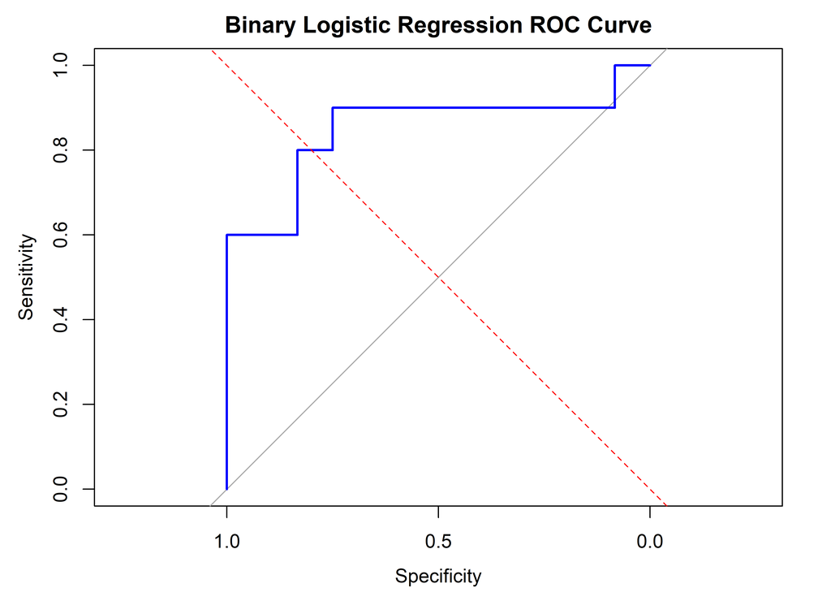

```r
#===============================================================
# ROC Curve
#===============================================================

roc_curve <- roc(
  response = y_test,
  predictor = prob_predictions$CRC,
  levels = c("healthy", "CRC")
)
plot(
  roc_curve,
  col = "blue",
  lwd = 2,
  main = "Binary Logistic Regression ROC Curve"
)

abline(
  a = 0,
  b = 1,
  lty = 2,
  col = "red"
)
```

```r
png(file.path(figures_dir, "ROC_Curve.png"), width = 15, height = 10, units = "in", res = 300)

plot(roc_curve)

dev.off()
## png
##   2
```

# 18 AUC

```r
#===============================================================
# AUC
#===============================================================
auc_value <- auc(roc_curve)

auc_results <- data.frame(
  AUC = as.numeric(auc_value)
)

write.csv(
  auc_results,
  file.path(
    results_dir,
    "BinomialLR_AUC.csv"
  ),
  row.names = FALSE
)

cat("AUC saved successfully.\n")
## AUC saved successfully.
```

# 19 ROC Coordinates

```r
#===============================================================
# ROC Coordinates
#===============================================================
roc_coordinates <- data.frame(
  Specificity = roc_curve$specificities,
  Sensitivity = roc_curve$sensitivities,
  Threshold = roc_curve$thresholds
)

write.csv(
  roc_coordinates,
  file.path(
    results_dir,
    "BinomialLR_ROC_Coordinates.csv"
  ),
  row.names = FALSE
)

cat("ROC coordinates saved successfully.\n")
## ROC coordinates saved successfully.
```

# 20 Logistic Regression Coefficients

```r
#===============================================================
# Logistic Regression Coefficients
#===============================================================

coefficients_table <- summary(logistic_model)$coefficients

coefficients_table
```

```
##                                                                                                                                                   Estimate
## (Intercept)                                                                                                                                    -162.974863
## k__Bacteria.p__Firmicutes.c__Clostridia.o__Clostridiales.f__Lachnospiraceae.g__Anaerostipes.s__Anaerostipes_hadrus                                1.425149
## k__Bacteria.p__Firmicutes.c__Clostridia.o__Clostridiales.f__Lachnospiraceae.g__Lachnospiraceae_unclassified.s__Eubacterium_rectale                3.508308
## k__Bacteria.p__Firmicutes.c__Clostridia.o__Clostridiales.f__Eubacteriaceae.g__Eubacterium.s__Eubacterium_hallii                                  -1.511105
## k__Bacteria.p__Bacteroidetes.c__Bacteroidia.o__Bacteroidales.f__Bacteroidaceae.g__Bacteroides.s__Bacteroides_uniformis                           -3.782302
## k__Bacteria.p__Firmicutes.c__Clostridia.o__Clostridiales.f__Ruminococcaceae.g__Ruminococcus.s__Ruminococcus_bicirculans                           7.067063
## k__Bacteria.p__Firmicutes.c__Clostridia.o__Clostridiales.f__Oscillospiraceae.g__Oscillibacter.s__Oscillibacter_sp_CAG_241                         2.132766
## k__Bacteria.p__Firmicutes.c__Clostridia.o__Clostridiales.f__Lachnospiraceae.g__Blautia.s__Blautia_wexlerae                                        4.557459
## k__Bacteria.p__Firmicutes.c__Clostridia.o__Clostridiales.f__Ruminococcaceae.g__Ruthenibacterium.s__Ruthenibacterium_lactatiformans               -1.226324
## k__Bacteria.p__Proteobacteria.c__Deltaproteobacteria.o__Desulfovibrionales.f__Desulfovibrionaceae.g__Bilophila.s__Bilophila_wadsworthia           1.711372
## k__Bacteria.p__Firmicutes.c__Bacilli.o__Lactobacillales.f__Streptococcaceae.g__Streptococcus.s__Streptococcus_salivarius                         10.115992
## k__Bacteria.p__Firmicutes.c__Clostridia.o__Clostridiales.f__Peptostreptococcaceae.g__Intestinibacter.s__Intestinibacter_bartlettii                2.470444
## k__Bacteria.p__Proteobacteria.c__Betaproteobacteria.o__Burkholderiales.f__Sutterellaceae.g__Turicimonas.s__Turicimonas_muris                      1.760186
## k__Bacteria.p__Firmicutes.c__Tissierellia.o__Tissierellales.f__Peptoniphilaceae.g__Parvimonas.s__Parvimonas_micra                               -47.505673
## k__Bacteria.p__Firmicutes.c__Clostridia.o__Clostridiales.f__Ruminococcaceae.g__Flavonifractor.s__Flavonifractor_plautii                          -3.884323
## k__Bacteria.p__Firmicutes.c__Clostridia.o__Clostridiales.f__Clostridiaceae.g__Hungatella.s__Hungatella_hathewayi                                -10.402149
## k__Bacteria.p__Firmicutes.c__Negativicutes.o__Veillonellales.f__Veillonellaceae.g__Dialister.s__Dialister_pneumosintes                           -8.250414
## k__Bacteria.p__Firmicutes.c__Clostridia.o__Clostridiales.f__Peptostreptococcaceae.g__Peptostreptococcus.s__Peptostreptococcus_stomatis         -805.759937
## k__Bacteria.p__Proteobacteria.c__Deltaproteobacteria.o__Desulfovibrionales.f__Desulfovibrionaceae.g__Desulfovibrio.s__Desulfovibrio_piger       -28.092776
## k__Bacteria.p__Firmicutes.c__Clostridia.o__Clostridiales.f__Clostridiales_Family_XIII_Incertae_Sedis.g__Mogibacterium.s__Mogibacterium_timidum   -7.502304
## k__Bacteria.p__Fusobacteria.c__Fusobacteriia.o__Fusobacteriales.f__Fusobacteriaceae.g__Fusobacterium.s__Fusobacterium_nucleatum                 -13.320583
##                                                                                                                                                 Std. Error
## (Intercept)                                                                                                                                    2120.117847
## k__Bacteria.p__Firmicutes.c__Clostridia.o__Clostridiales.f__Lachnospiraceae.g__Anaerostipes.s__Anaerostipes_hadrus                                1.370180
## k__Bacteria.p__Firmicutes.c__Clostridia.o__Clostridiales.f__Lachnospiraceae.g__Lachnospiraceae_unclassified.s__Eubacterium_rectale                2.960711
```

[output cut: 62 more lines]

```r
#===============================================================
# Extract Model Coefficients
#===============================================================

coefficients_df <- data.frame(
  Feature = names(coef(logistic_model$finalModel)),
  Estimate = coef(logistic_model$finalModel)
)

# Remove intercept
coefficients_df <- coefficients_df[
  coefficients_df$Feature != "(Intercept)",
]

coefficients_df
```

|  | Feature | Estimate |
| --- | --- | --- |
| k__Bacteria.p__Firmicutes.c__Clostridia.o__Clostridiales.f__Lachnospiraceae.g__Anaerostipes.s__Anaerostipes_hadrus | k__Bacteria.p__Firmicutes.c__Clostridia.o__Clostridiales.f__Lachnospiraceae.g__Anaerostipes.s__Anaerostipes_hadrus | 1.425149 |
| k__Bacteria.p__Firmicutes.c__Clostridia.o__Clostridiales.f__Lachnospiraceae.g__Lachnospiraceae_unclassified.s__Eubacterium_rectale | k__Bacteria.p__Firmicutes.c__Clostridia.o__Clostridiales.f__Lachnospiraceae.g__Lachnospiraceae_unclassified.s__Eubacterium_rectale | 3.508308 |
| k__Bacteria.p__Firmicutes.c__Clostridia.o__Clostridiales.f__Eubacteriaceae.g__Eubacterium.s__Eubacterium_hallii | k__Bacteria.p__Firmicutes.c__Clostridia.o__Clostridiales.f__Eubacteriaceae.g__Eubacterium.s__Eubacterium_hallii | -1.511105 |
| k__Bacteria.p__Bacteroidetes.c__Bacteroidia.o__Bacteroidales.f__Bacteroidaceae.g__Bacteroides.s__Bacteroides_uniformis | k__Bacteria.p__Bacteroidetes.c__Bacteroidia.o__Bacteroidales.f__Bacteroidaceae.g__Bacteroides.s__Bacteroides_uniformis | -3.782302 |
| k__Bacteria.p__Firmicutes.c__Clostridia.o__Clostridiales.f__Ruminococcaceae.g__Ruminococcus.s__Ruminococcus_bicirculans | k__Bacteria.p__Firmicutes.c__Clostridia.o__Clostridiales.f__Ruminococcaceae.g__Ruminococcus.s__Ruminococcus_bicirculans | 7.067063 |
| k__Bacteria.p__Firmicutes.c__Clostridia.o__Clostridiales.f__Oscillospiraceae.g__Oscillibacter.s__Oscillibacter_sp_CAG_241 | k__Bacteria.p__Firmicutes.c__Clostridia.o__Clostridiales.f__Oscillospiraceae.g__Oscillibacter.s__Oscillibacter_sp_CAG_241 | 2.132766 |
| k__Bacteria.p__Firmicutes.c__Clostridia.o__Clostridiales.f__Lachnospiraceae.g__Blautia.s__Blautia_wexlerae | k__Bacteria.p__Firmicutes.c__Clostridia.o__Clostridiales.f__Lachnospiraceae.g__Blautia.s__Blautia_wexlerae | 4.557459 |
| k__Bacteria.p__Firmicutes.c__Clostridia.o__Clostridiales.f__Ruminococcaceae.g__Ruthenibacterium.s__Ruthenibacterium_lactatiformans | k__Bacteria.p__Firmicutes.c__Clostridia.o__Clostridiales.f__Ruminococcaceae.g__Ruthenibacterium.s__Ruthenibacterium_lactatiformans | -1.226324 |
| k__Bacteria.p__Proteobacteria.c__Deltaproteobacteria.o__Desulfovibrionales.f__Desulfovibrionaceae.g__Bilophila.s__Bilophila_wadsworthia | k__Bacteria.p__Proteobacteria.c__Deltaproteobacteria.o__Desulfovibrionales.f__Desulfovibrionaceae.g__Bilophila.s__Bilophila_wadsworthia | 1.711372 |
| k__Bacteria.p__Firmicutes.c__Bacilli.o__Lactobacillales.f__Streptococcaceae.g__Streptococcus.s__Streptococcus_salivarius | k__Bacteria.p__Firmicutes.c__Bacilli.o__Lactobacillales.f__Streptococcaceae.g__Streptococcus.s__Streptococcus_salivarius | 10.115992 |

[output cut: 10 more lines]

```r
write.csv(
  coefficients_df,
  file.path(
    results_dir,
    "BinomialLR_Coefficients.csv"
  ),
  row.names = FALSE
)

cat("Coefficient table saved successfully.\n")
## Coefficient table saved successfully.
```

# 21 Calculate Odds Ratios

```r
#===============================================================
# Calculate Odds Ratios
#===============================================================

coefficients_df$OddsRatio <- exp(coefficients_df$Estimate)

coefficients_df
```

|  | Feature | Estimate | OddsRatio |
| --- | --- | --- | --- |
| k__Bacteria.p__Firmicutes.c__Clostridia.o__Clostridiales.f__Lachnospiraceae.g__Anaerostipes.s__Anaerostipes_hadrus | k__Bacteria.p__Firmicutes.c__Clostridia.o__Clostridiales.f__Lachnospiraceae.g__Anaerostipes.s__Anaerostipes_hadrus | 1.425149 | 4.158477475351818775095580349 |
| k__Bacteria.p__Firmicutes.c__Clostridia.o__Clostridiales.f__Lachnospiraceae.g__Lachnospiraceae_unclassified.s__Eubacterium_rectale | k__Bacteria.p__Firmicutes.c__Clostridia.o__Clostridiales.f__Lachnospiraceae.g__Lachnospiraceae_unclassified.s__Eubacterium_rectale | 3.508308 | 33.391733815345681080088979797 |
| k__Bacteria.p__Firmicutes.c__Clostridia.o__Clostridiales.f__Eubacteriaceae.g__Eubacterium.s__Eubacterium_hallii | k__Bacteria.p__Firmicutes.c__Clostridia.o__Clostridiales.f__Eubacteriaceae.g__Eubacterium.s__Eubacterium_hallii | -1.511105 | 0.220666006782175877498630712 |
| k__Bacteria.p__Bacteroidetes.c__Bacteroidia.o__Bacteroidales.f__Bacteroidaceae.g__Bacteroides.s__Bacteroides_uniformis | k__Bacteria.p__Bacteroidetes.c__Bacteroidia.o__Bacteroidales.f__Bacteroidaceae.g__Bacteroides.s__Bacteroides_uniformis | -3.782302 | 0.022770205661098722599300359 |
| k__Bacteria.p__Firmicutes.c__Clostridia.o__Clostridiales.f__Ruminococcaceae.g__Ruminococcus.s__Ruminococcus_bicirculans | k__Bacteria.p__Firmicutes.c__Clostridia.o__Clostridiales.f__Ruminococcaceae.g__Ruminococcus.s__Ruminococcus_bicirculans | 7.067063 | 1172.698887121111283704522065818 |
| k__Bacteria.p__Firmicutes.c__Clostridia.o__Clostridiales.f__Oscillospiraceae.g__Oscillibacter.s__Oscillibacter_sp_CAG_241 | k__Bacteria.p__Firmicutes.c__Clostridia.o__Clostridiales.f__Oscillospiraceae.g__Oscillibacter.s__Oscillibacter_sp_CAG_241 | 2.132766 | 8.438171865509024982543451188 |
| k__Bacteria.p__Firmicutes.c__Clostridia.o__Clostridiales.f__Lachnospiraceae.g__Blautia.s__Blautia_wexlerae | k__Bacteria.p__Firmicutes.c__Clostridia.o__Clostridiales.f__Lachnospiraceae.g__Blautia.s__Blautia_wexlerae | 4.557459 | 95.340895849797277605830458924 |
| k__Bacteria.p__Firmicutes.c__Clostridia.o__Clostridiales.f__Ruminococcaceae.g__Ruthenibacterium.s__Ruthenibacterium_lactatiformans | k__Bacteria.p__Firmicutes.c__Clostridia.o__Clostridiales.f__Ruminococcaceae.g__Ruthenibacterium.s__Ruthenibacterium_lactatiformans | -1.226324 | 0.293369109264172034379214438 |
| k__Bacteria.p__Proteobacteria.c__Deltaproteobacteria.o__Desulfovibrionales.f__Desulfovibrionaceae.g__Bilophila.s__Bilophila_wadsworthia | k__Bacteria.p__Proteobacteria.c__Deltaproteobacteria.o__Desulfovibrionales.f__Desulfovibrionaceae.g__Bilophila.s__Bilophila_wadsworthia | 1.711372 | 5.536553820849269946791082475 |
| k__Bacteria.p__Firmicutes.c__Bacilli.o__Lactobacillales.f__Streptococcaceae.g__Streptococcus.s__Streptococcus_salivarius | k__Bacteria.p__Firmicutes.c__Bacilli.o__Lactobacillales.f__Streptococcaceae.g__Streptococcus.s__Streptococcus_salivarius | 10.115992 | 24735.431449333849741378799080849 |

[output cut: 10 more lines]

# 22 Sort by Absolute Effect

```r
#===============================================================
# Sort Features by Effect Size
#===============================================================

coefficients_df <- coefficients_df[
  order(abs(coefficients_df$Estimate),
        decreasing = TRUE),
]

head(coefficients_df, 20)
```

|  | Feature | Estimate | OddsRatio |
| --- | --- | --- | --- |
| k__Bacteria.p__Firmicutes.c__Clostridia.o__Clostridiales.f__Peptostreptococcaceae.g__Peptostreptococcus.s__Peptostreptococcus_stomatis | k__Bacteria.p__Firmicutes.c__Clostridia.o__Clostridiales.f__Peptostreptococcaceae.g__Peptostreptococcus.s__Peptostreptococcus_stomatis | -805.759937 | 0.000000000000000000000000000 |
| k__Bacteria.p__Firmicutes.c__Tissierellia.o__Tissierellales.f__Peptoniphilaceae.g__Parvimonas.s__Parvimonas_micra | k__Bacteria.p__Firmicutes.c__Tissierellia.o__Tissierellales.f__Peptoniphilaceae.g__Parvimonas.s__Parvimonas_micra | -47.505673 | 0.000000000000000000002336407 |
| k__Bacteria.p__Proteobacteria.c__Deltaproteobacteria.o__Desulfovibrionales.f__Desulfovibrionaceae.g__Desulfovibrio.s__Desulfovibrio_piger | k__Bacteria.p__Proteobacteria.c__Deltaproteobacteria.o__Desulfovibrionales.f__Desulfovibrionaceae.g__Desulfovibrio.s__Desulfovibrio_piger | -28.092776 | 0.000000000000630176973846223 |
| k__Bacteria.p__Fusobacteria.c__Fusobacteriia.o__Fusobacteriales.f__Fusobacteriaceae.g__Fusobacterium.s__Fusobacterium_nucleatum | k__Bacteria.p__Fusobacteria.c__Fusobacteriia.o__Fusobacteriales.f__Fusobacteriaceae.g__Fusobacterium.s__Fusobacterium_nucleatum | -13.320583 | 0.000001640379830601932840744 |
| k__Bacteria.p__Firmicutes.c__Clostridia.o__Clostridiales.f__Clostridiaceae.g__Hungatella.s__Hungatella_hathewayi | k__Bacteria.p__Firmicutes.c__Clostridia.o__Clostridiales.f__Clostridiaceae.g__Hungatella.s__Hungatella_hathewayi | -10.402149 | 0.000030367141702747628591308 |
| k__Bacteria.p__Firmicutes.c__Bacilli.o__Lactobacillales.f__Streptococcaceae.g__Streptococcus.s__Streptococcus_salivarius | k__Bacteria.p__Firmicutes.c__Bacilli.o__Lactobacillales.f__Streptococcaceae.g__Streptococcus.s__Streptococcus_salivarius | 10.115992 | 24735.431449333849741378799080849 |
| k__Bacteria.p__Firmicutes.c__Negativicutes.o__Veillonellales.f__Veillonellaceae.g__Dialister.s__Dialister_pneumosintes | k__Bacteria.p__Firmicutes.c__Negativicutes.o__Veillonellales.f__Veillonellaceae.g__Dialister.s__Dialister_pneumosintes | -8.250414 | 0.000261150456834746171053130 |
| k__Bacteria.p__Firmicutes.c__Clostridia.o__Clostridiales.f__Clostridiales_Family_XIII_Incertae_Sedis.g__Mogibacterium.s__Mogibacterium_timidum | k__Bacteria.p__Firmicutes.c__Clostridia.o__Clostridiales.f__Clostridiales_Family_XIII_Incertae_Sedis.g__Mogibacterium.s__Mogibacterium_timidum | -7.502304 | 0.000551811266017886029380812 |
| k__Bacteria.p__Firmicutes.c__Clostridia.o__Clostridiales.f__Ruminococcaceae.g__Ruminococcus.s__Ruminococcus_bicirculans | k__Bacteria.p__Firmicutes.c__Clostridia.o__Clostridiales.f__Ruminococcaceae.g__Ruminococcus.s__Ruminococcus_bicirculans | 7.067063 | 1172.698887121111283704522065818 |
| k__Bacteria.p__Firmicutes.c__Clostridia.o__Clostridiales.f__Lachnospiraceae.g__Blautia.s__Blautia_wexlerae | k__Bacteria.p__Firmicutes.c__Clostridia.o__Clostridiales.f__Lachnospiraceae.g__Blautia.s__Blautia_wexlerae | 4.557459 | 95.340895849797277605830458924 |

[output cut: 10 more lines]

# 23 Logistic Regression Coefficient Plot

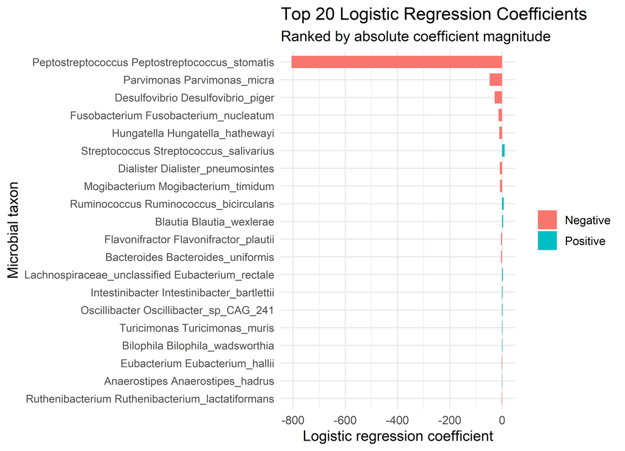

```r
# ================================================================
# Logistic Regression Coefficients and Top Biomarkers
# ================================================================

# Extract coefficients from the final fitted logistic model
coefficients_df <- data.frame(
  Feature = names(coef(logistic_model$finalModel)),
  Estimate = as.numeric(coef(logistic_model$finalModel)),
  stringsAsFactors = FALSE
)

# Remove intercept
coefficients_df <- coefficients_df[
  coefficients_df$Feature != "(Intercept)",
  ,
  drop = FALSE
]

# Calculate odds ratios
coefficients_df$OddsRatio <- exp(coefficients_df$Estimate)

# ================================================================
# Extract Genus + Species names
# ================================================================

extract_microbe_name <- function(x) {

  genus <- stringr::str_match(
    x,
    "g__([^.|]+)"
  )[, 2]

  species <- stringr::str_match(
    x,
    "s__([^.|]+)"
  )[, 2]

  if (
    !is.na(genus) &&
    !is.na(species)
  ) {
    return(
      paste(
        genus,
        species
      )
    )
  }

  # Fallback to original feature name
  return(x)
}

coefficients_df$Microbe <- vapply(
  coefficients_df$Feature,
  extract_microbe_name,
  character(1)
)

# ================================================================
# Rank features by absolute coefficient magnitude
# ================================================================

coefficients_df <- coefficients_df[
  order(
    abs(coefficients_df$Estimate),
    decreasing = TRUE
  ),
  ,
  drop = FALSE
]

coefficients_df$Rank <- seq_len(
  nrow(coefficients_df)
)

# ================================================================
# Save complete coefficient table
# ================================================================

write.csv(
  coefficients_df,
  file.path(
    results_dir,
    "BinomialLR_Coefficients.csv"
  ),
  row.names = FALSE
)

# ================================================================
# Extract Top 20 Biomarkers
# ================================================================

top20_biomarkers <- head(
  coefficients_df,
  20
)

top20_biomarkers$Direction <- ifelse(
  top20_biomarkers$Estimate > 0,
  "Positive",
  "Negative"
)

# Save dedicated Top-20 biomarker table
write.csv(
  top20_biomarkers,
  file.path(
    results_dir,
    "BinomialLR_Top20Biomarkers.csv"
  ),
  row.names = FALSE
)

# ================================================================
# Create Top-20 coefficient plot
# ================================================================

coefficient_plot <- ggplot(
  top20_biomarkers,
  aes(
    x = reorder(
      Microbe,
      abs(Estimate)
    ),
    y = Estimate,
    fill = Direction
  )
) +

  geom_col(
    width = 0.70
  ) +

  coord_flip() +

  labs(
    title = "Top 20 Logistic Regression Coefficients",
    subtitle = "Ranked by absolute coefficient magnitude",
    x = "Microbial taxon",
    y = "Logistic regression coefficient"
  ) +

  theme_minimal(
    base_size = 12
  ) +

  theme(
    legend.title = element_blank(),
    axis.text.y = element_text(
      size = 9
    )
  )

# Display in knitted HTML
print(coefficient_plot)
```

```r
# ================================================================
# Save publication-quality figure
# ================================================================

ggsave(
  filename = file.path(
    figures_dir,
    "BinomialLR_Coefficients.png"
  ),
  plot = coefficient_plot,
  width = 9,
  height = 7,
  dpi = 300
)

cat(
  "Logistic regression coefficient table, Top-20 biomarker table, ",
  "and coefficient plot saved successfully.\n"
)
## Logistic regression coefficient table, Top-20 biomarker table,  and coefficient plot saved successfully.
```

# 24 Save Trained Model

```r
#===============================================================
# Save Trained Model
#===============================================================

saveRDS(
  logistic_model,
  file.path(
    models_dir,
    "BinomialLR_Model.rds"
  )
)
file.exists(
  file.path(
    models_dir,
    "BinomialLR_Model.rds"
  )
)
```

```
## [1] TRUE
```

```r
cat("Model saved successfully.\n")
## Model saved successfully.
```

# 25 Session Information

```r
#===============================================================
# Session Information
#===============================================================

writeLines(
  file.path(
    reports_dir,
    "BinomialLR_SessionInfo.txt"
  )
)
```

[session information not shown]

## 25.1 Session information

The final section records the exact R session used for this knit. The same information is also saved as a text artifact so the HTML report and repository contain both a human-readable and machine-readable provenance record.

```r
session_file <- file.path(
  results_dir,
  "session_info",
  "01_Binomial_Logistic_Regression_sessionInfo.txt"
)
cat("Saved session information to:", session_file, "\n\n")
## Saved session information to: C:/CRC/CRC_Quantum_Microbiome_Githb/CRC_Quantum_Microbiome_GitHub_RMD/02 Classical ML/results/session_info/01_Binomial_Logistic_Regression_sessionInfo.txt
```

[session information not shown]